# Assignment 12

Hughes, O’Connell, Wang

Sections A,C: Wednesday, October 16, 2019 Section B: Thursday, October 17, 2019

# Analysis of Covariance (ANCOVA)

In the most general sense, ANCOVA can be though of as a regression problem that contains both numeric and categorical predictors. This isn’t exactly what it really means, however – in its origin, ANCOVA was a technique for investigating the effect of a factor on a response variable (this could be through a designed experiment or an observational study) after adjusting for the impact of some measured predictor variable, called a **covariate**.

For example, consider a weight loss study comparing the effects of two different diets on weight loss. We randomly assign one of the two diets to each of the subjects; they participate in their assigned diet, and then their weight loss is measured after 12 weeks. In such a scenario, we might want to use a subject-specific fitness measure (like BMI) as a **covariate** in the analysis. It is possible that the effectivenes of a diet (measured by weight loss) might be affected by the physical size of the subject. For example, someone with a higher BMI might have more potential for weight loss regardless of the diet thet are on. So, it makes sense to account for this in the regression by also modeling it alongside the categorical `Diet` factor. By doing so, we are not necessily interested in the effect `BMI` might have on weight loss – all we are doing is recognizing that it *may* have an effect, so it is smart to account for it when modeling.

## Example: The effect of smoking on the birth weight of newborns

The data set `babies.RData` contains information on the birth weights of newborns and if the mother has a history of smoking or not. The weight of the mother at the time of delivery is also provided. The goal of the study is to investigate the hypothesis that smoking is associated with lower average birth weight in babies. Of course, the weight of the mother may also be a determining factor in baby weight, so the effect of smoking should be adjusted for this. This calls for an ANCOVA.

The variables are:

- `momwt` - Weight of the mother (in pounds) at the time of delivery
- `smoker` - Smoking status of the mother (a logical variable)
- `babywt` - Birth weight of a newborn (in ounces)

Note that the data already reside in an R workspace (i.e. it is not in a .csv or .txt file), so we use the `load()` function in R. The workspace data already has the name `babies`:

```r
load("babies.Rdata")
head(babies)
```

```
##   momwt smoker babywt
## 1   100  FALSE    120
## 2   135  FALSE    113
## 3   115   TRUE    128
## 4   190   TRUE    123
## 5   125   TRUE    108
## 6    93   TRUE    136
```

### EDA

Birth weight (`babywt`) is the response variable here. Let’s create a scatterplot of birth weight vs. weight of the mother by smoking status.

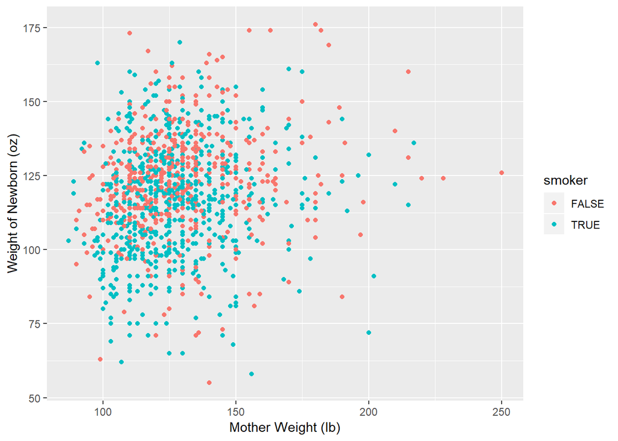

```r
edaplot <- ggplot(babies, aes(x=momwt, y=babywt, color=smoker)) +
  geom_point() +
  xlab("Mother Weight (lb)") +
  ylab("Weight of Newborn (oz)")
edaplot
```

First we see there is a lot of data here, and it is hard to distinguish between the smokers and non-smoking mothers. Let’s add a regression line for each smoking status to see the linear trends suggested by the data:

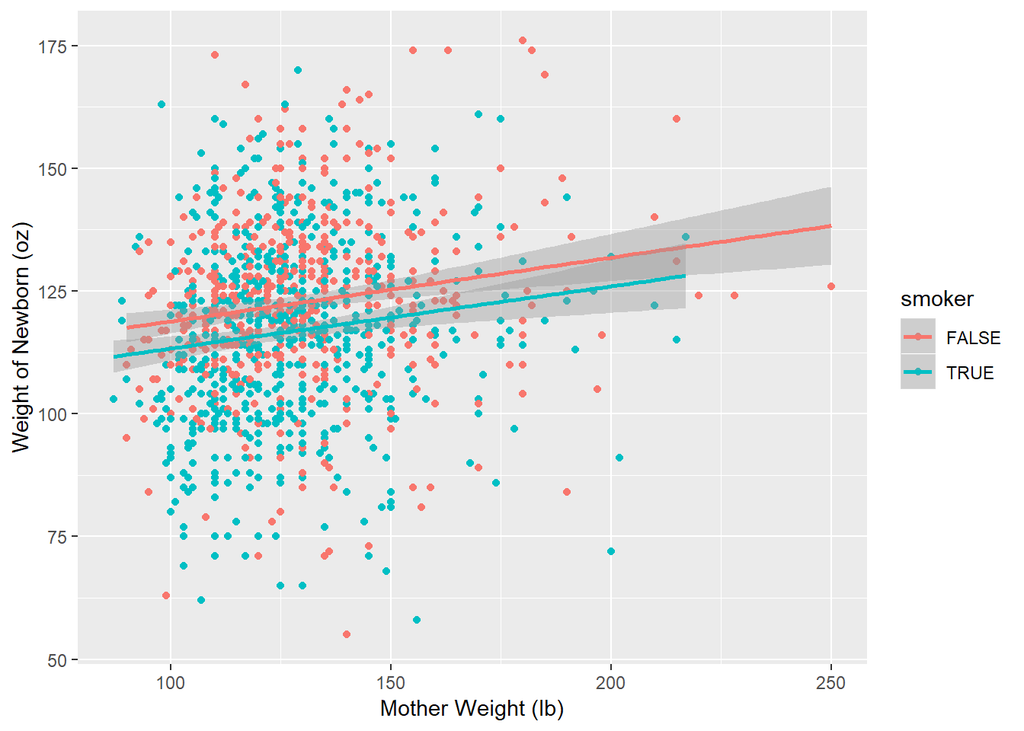

```r
edaplot +
  geom_smooth(method=lm)
```

*The effect of the mothers weight on the baby’s weight seems to be the same regardless if she was in the smooking group of non-smoking group. The liner model of the non-smokers babies are slighlty larger than that of smokers, regardless of the weight of the mother.*

Of key interest is the vertical gap *between* the trend lines of smokers and non-smokers. There appears to be some consistent detrimental effect of smoking on the birth weight of babies, regardless of the weight of the mother.

### ANCOVA MODEL 1: Interaction Model

When we write out such a model, you will see the road map as to what the model’s $\beta$-coefficients actually represent in context. The interaction model is given by:

$$BabyWt = \beta_0 + \beta_1(MomWt) + \beta_2(I_{Smoker}) + \beta_3(MomWt*I_{Smoker}) + \varepsilon$$

where the variable $I_{Smoker}$ is 1 if the mother is a smoker, and 0 if not.

**ASIDE**. Note that the R variable `smoker` is actually a **logical variable** in the data set:

```r
class(babies$smoker)
```

```
## [1] "logical"
```

Internally, a logical variable in R has values `TRUE` and `FALSE` (you saw that in the scatterplots above), but when handling such variables arithmetically, R treats `TRUE` as 1 and `FALSE` as 0.

So what does this model look like under each of the `smoker` scenarios? Let’s check:

$$\begin{array}{ccc}
\hline
\textbf{Smoking Status} & \mathbf{I_{Smoker}} & \textbf{Model for mean response} \\
\hline
FALSE\ & 0 & \mu_{Non-smoker} = \beta_0 + \beta_1(MomWt) + \beta_2(0) + \beta_3(MomWt*0) = \beta_0 + \beta_1(MomWt) \\
TRUE\ & 1 & \mu_{Smoker} = \beta_0 + \beta_1(MomWt) + \beta_2(1) + \beta_3(MomWt*1) = (\beta_0 + \beta_2) + (\beta_1 + \beta_3)(MomWt) \\
\hline
\end{array}$$

Brilliant! A closer inspection will now reveal what each of this model’s $\beta$-parameters represents in context:

- $\beta_0$ represents the intercept of the line for non-smoking mothers; or, the mean weight of babies born to non-smoking mothers who weigh 0 pounds. **Clearly meaningless in context.**
- $\beta_1$ represents the slope of the line for non-smoking mothers; or, the change in mean weight of babies born to non-smoking mothers for each additional pound of weight of the mother.
- $\beta_2$ represents the **change** in the intercept of the line from non-smoking mothers to smoking mothers; or, the **change** in the mean weight of babies due to smoking, but specific to mothers weighing 0 pounds. **Also meaningless in context.**
- $\beta_3$ represents … *the change in the slope between non-smokers to the smoker linear model or it meausers the mean change in the weight of a baby in the weights of the babies going from the smokers to non-smokers.*

The test for the interaction term $MomWt*I_{Smoker}$ is the critical test at this juncture. If we can show that $\beta_3 \neq 0$, then we will establish that the effect of smoking on baby weight **depends on the weight of the mother**. This is what an interaction between these variables means in this context.

So, we fit the model (check assumptions first before using the model for inference):

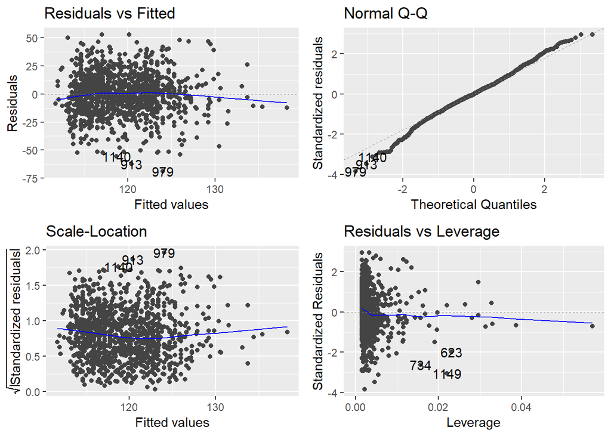

```r
ancova.model1 <- lm(babywt ~ momwt + smoker + momwt:smoker, data=babies)
autoplot(ancova.model1)
```

*This looks like a good model to perseve with; pretty much everything looks fine.*

```r
summary(ancova.model1)
```

```
##
## Call:
## lm(formula = babywt ~ momwt + smoker + momwt:smoker, data = babies)
##
## Residuals:
##     Min      1Q  Median      3Q     Max
## -69.025 -10.490  -0.359  11.055  53.008
##
## Coefficients:
##                    Estimate Std. Error t value Pr(>|t|)
## (Intercept)      105.843481   4.605936  22.980  < 2e-16 ***
## momwt              0.129865   0.034986   3.712 0.000215 ***
## smokerTRUE        -5.187454   6.485620  -0.800 0.423964
## momwt:smokerTRUE  -0.003227   0.049755  -0.065 0.948292
## ---
## Signif. codes:  0 '***' 0.001 '**' 0.01 '*' 0.05 '.' 0.1 ' ' 1
##
## Residual standard error: 17.91 on 1186 degrees of freedom
## Multiple R-squared:  0.04688,    Adjusted R-squared:  0.04447
## F-statistic: 19.45 on 3 and 1186 DF,  p-value: 2.607e-12
```

**This last result brings us to an important decision.** Because we have concluded that the effect of smoking is not tied to the weight of the mother, the interaction term can be deleted from the model, and we then have a **main-effects model**. Remember – simplify a regression model when you can, because this can make explanations of the results simpler!

### ANCOVA MODEL 2: Main Effects Model

It should be stated explicitly (again) that **we only choose to move to a main effects model because the interaction between the predictors under study was not significant.**

The main effects model just drops the interaction term(s). But, we must be aware of the ramifications on the interpretations of the $\beta$-coefficients that will result from doing so:

$$BabyWt = \beta_0 + \beta_1(MomWt) + \beta_2(I_{Smoker}) + \varepsilon$$
Model breakdown:

$$\begin{array}{ccc}
\hline
\textbf{Smoking Status} & \mathbf{I_{Smoker}} & \textbf{Model for mean response} \\
\hline
FALSE\ & 0 & \mu_{Non-smoker} = \beta_0 + \beta_1(MomWt) + \beta_2(0) = \beta_0 + \beta_1(MomWt) \\
TRUE\ & 1 & \mu_{Smoker} = \beta_0 + \beta_1(MomWt) + \beta_2(1) = (\beta_0 + \beta_2) + \beta_1(MomWt) \\
\hline
\end{array}$$

Note the differences in interpretations from before:

- $\beta_0$ now represents the intercept of the line for non-smoking mothers; or, the mean weight of babies born to non-smoking mothers weighing 0 pounds. Still meaningless in context.
- $\beta_1$ now represents the slope of the line for **either** non-smoking **or** smoking mothers; or, the change in mean weight of babies for each additional pound of weight of the mother, **regardless of whether or not the mother is a smoker**.
- $\beta_2$ now represents … *The shift in the intercepts of smoke and non-smoker linear models. Mean change in aby brith weight in mother after adjusted for weight of the mother.*

The test for $\beta_2$ addresses the main goal of the study. If we can show that $\beta_2 \neq 0$, then we will establish that there is an effect of smoking on baby weight **regardless of the weight of the mother**.

So, we fit the main effects model (check assumptions first):

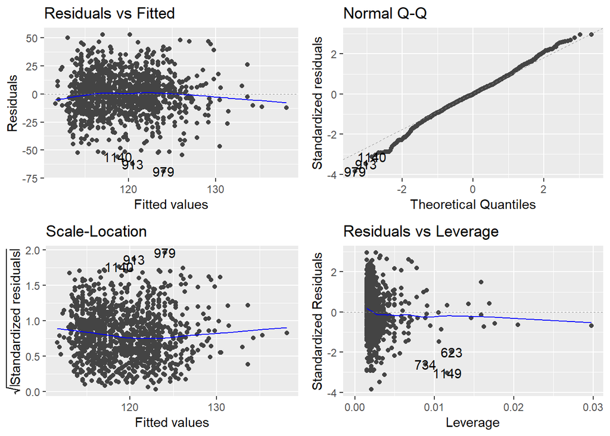

```r
ancova.model2 <- lm(babywt ~ momwt + smoker, data=babies)
autoplot(ancova.model2)
```

```r
summary(ancova.model2)
```

```
##
## Call:
## lm(formula = babywt ~ momwt + smoker, data = babies)
##
## Residuals:
##     Min      1Q  Median      3Q     Max
## -69.008 -10.510  -0.353  11.078  53.005
##
## Coefficients:
##              Estimate Std. Error t value Pr(>|t|)
## (Intercept) 106.05055    3.31885  31.954  < 2e-16 ***
## momwt         0.12827    0.02487   5.159 2.91e-07 ***
## smokerTRUE   -5.60264    1.04571  -5.358 1.01e-07 ***
## ---
## Signif. codes:  0 '***' 0.001 '**' 0.01 '*' 0.05 '.' 0.1 ' ' 1
##
## Residual standard error: 17.91 on 1187 degrees of freedom
## Multiple R-squared:  0.04688,    Adjusted R-squared:  0.04527
## F-statistic: 29.19 on 2 and 1187 DF,  p-value: 4.213e-13
```

Note the slight rise in the adjusted $R^2$ as compared to the interaction model. Here’s the test of interest:

- $H_0:\beta_2 = 0$ (smoking has **no** effect on mean baby weight (after adjusting for mother’s weight))
- $H_a:\beta_2 \neq 0$ (smoking **has** an effect on mean baby weight (after adjusting for mother’s weight))
- The test statistic is $t$ = -5.358, with a $p$-value of $10^{-7}$. We reject $H_0$. **Smoking has an effect on mean baby weight after adjusting for mother’s weight.**

**Estimate the effect.** We can look at the model’s estimate of $\beta_2$, which is $\hat{\beta}_2$ = -5.602. This means that we estimate that smoking mothers will birth babies whose mean weight is 5.6 ounces *lower* than that of non-smiking mothers. Better yet, we can establish a confidence interval for this:

```r
confint(ancova.model2)
```

```
##                   2.5 %      97.5 %
## (Intercept) 99.53908592 112.5620143
## momwt        0.07948405   0.1770551
## smokerTRUE  -7.65429432  -3.5509838
```

*INTERPRETATION: We can be 95% confident that, regardless of the weigh of the mother, smoking is going to induce a mean drop in birth weight of between 3.55 oz to about 7.65 ounces.*

**Using the model for response prediction.** Even though the model’s $R^2$ is not very impressive, we can still use the model for prediction if we are satisfied that it is a good model. Just be aware that any predictions or estimation of the response `babywt` may have some lack of precision.

Let’s use the main effects ANCOVA model to find and interpret separate 95% confidence intervals for

- the true mean birth weight of newborns of all mothers of average weight who have a history of smoking
- the true mean birth weight of newborns of all mothers of average weight who have no smoking history.

First, determine the mean weight of mothers in the sample (as our estimate of “average mother weight”):

```r
mean(babies$momwt)
```

```
## [1] 128.537
```

Now, the two CIs:

```r
predict(ancova.model2, newdata=data.frame(momwt=128.54, smoker=TRUE), int="conf")
```

```
##        fit      lwr      upr
## 1 116.9357 115.5662 118.3051
```

```r
predict(ancova.model2, newdata=data.frame(momwt=128.54, smoker=FALSE), int="conf")
```

```
##        fit      lwr      upr
## 1 122.5383 121.0125 124.0641
```

## QUESTIONS

*Answer the following* with justification based on the output:

1. Predict, with 95% confidence, the birth weight of a newborn born of a mother weighing 128.54 pounds who has a history of smoking. Interpret the interval in context. (How does this compare to the first CI we got above?)

```r
predict(ancova.model2, newdata=data.frame(momwt=128.54, smoker=TRUE), int="predict")
```

```
##        fit      lwr      upr
## 1 116.9357 81.77559 152.0958
```

We are 95% sure that for a mother who weighs 128.54 pounds who has a history of smoking their baby’s weight will be between 81.77559 oz and 152.0958 oz. This 95% confidence interval is larger than the confidence interval.

2. Predict, with 95% confidence, the birth weight of a newborn born of a mother weighing 180 pounds who has a history of smoking. Interpret the interval in context.

```r
predict(ancova.model2, newdata=data.frame(momwt=180, smoker=TRUE), int="predict")
```

```
##        fit      lwr      upr
## 1 123.5364 88.28339 158.7895
```

3. Using the interaction model instead, re-do question 2. How does the result compare when using the earlier model?

```r
predict(ancova.model1, newdata=data.frame(momwt=128.54, smoker=TRUE), int="predict")
```

```
##        fit      lwr     upr
## 1 116.9341 81.75915 152.109
```

4. Refer to the interaction model. Based on the model output, write out the fitted model for the mean response for **non-smoking mothers**, and also for **smoking mothers**. Simplify the answers as much as possible.

105.843481+0.129865(MomWt)

( 100.66)+(0.12))(MomWt)

5. Now refer to the main effects model. Based on the model output, write out the fitted model for the mean response for **non-smoking mothers**, and also for **smoking mothers**. Simplify the answers as much as possible.

106.05055+0.128271(MomWt)

(100.45))+0.12827(MomWt)

6. Compare the results in questions 4 and 5. What do you notice between the different model representations?

They have the same coffecient for the mom weight and different B0. They are acutally pretty similar whcih explains why we get the same answer for them.